# Data Products Week 4 Assignment

23 January 2018

## Run Prediction

- The Shiny app predicts your race pace (seconds or minutes per kilometer) based upon your cadence (strides per minute).
- It is based upon personal Garmin data gathered over the course of a number of years.
- Predictions are based on a linear model of outcome average pace with predictor of average cadence.
- Predictions are averaged across multiple terrains, elevation and weather.
- A future release of this product will enable users to input these other predictors.
1. App: https://sacooper74.shinyapps.io/courseproject/
2. GitHub: https://github.com/sacooper74/ds_9_dp_wk4

## Structure of Data

The data is based upon personal Garmin data gathered over a course of a number of years.

The dataset has 94 rows and 12 columns. Field names and header:

```
##  [1] "Distance"    "Calories"    "Time"        "AvgHR"       "MaxHR"
##  [6] "TE"          "AvgCadence"  "AvgPace"     "AvgVertical" "AvgGCT"
## [11] "ElevGain"    "pace_num"
```

```
## # A tibble: 1 x 12
##   Distance Calories Time  AvgHR MaxHR    TE AvgCadence AvgPace AvgVertical
##      <dbl>    <dbl> <tim> <int> <int> <dbl>      <dbl> <time>        <dbl>
## 1     10.9      734    NA   157   179  4.40        180 05'19"         7.10
## # ... with 3 more variables: AvgGCT <int>, ElevGain <int>, pace_num <dbl>
```

## The Model ~ Correlation, Coefficients and R Squared

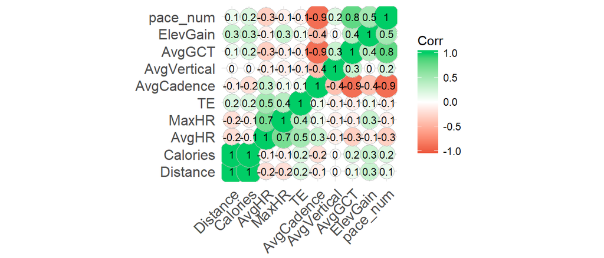

The linear model shows that pace decreases by -3.29 seconds for every unit increase in strides per minute. This relationship accounts for more than 0.79 of the variance in pace.

## Appendix

### References

1. Loading a dataset into Shiny: https://deanattali.com/blog/building-shiny-apps-tutorial/#4-load-the-dataset
2. Getting started with Shiny apps: https://shiny.rstudio.com/articles/shinyapps.html
3. Help with disconnection error in Shiny: https://support.rstudio.com/hc/en-us/articles/220339568-What-does-Disconnected-from-Server-mean-in-shinyapps-io-
4. Time as numeric for correlations: https://stackoverflow.com/questions/20077944/changing-dates-into-numeric-form-to-do-a-correlation
5. ioslides from R Studio: http://rmarkdown.rstudio.com/ioslides_presentation_format.html#overview